# Projeto de Análise de Dados em R - Aula 4

# Modelos Categóricos de Regressão

##### Carregar e tratar dados

```r
# carregar banco de dados
load("Latinobarometro_2015_Eng.rdata")
```

```r
# selecionar colunas no banco por nome
database <- Latinobarometro_2015_Eng[, c("P20TGB.A", "P21ST.C", "P32N", "P63NJ.G",
    "S23", "S12", "S6", "S24.K", "S18")]

# renomear colunas
colnames(database) <- c("conversa_sobre_politica", "participa_protestos", "interesse_político",
    "violencia_policial", "raca", "genero", "classe_social", "esgotamento",
    "escolaridade")

# selecionar casos completos (remover missing cases)
databaseClean <- database[complete.cases(database), ]
```

## Regressão Logística Binomial (Binomial Logit Reg.)

Utilizamos o modelo de regressão logística binomial quando o fenômeno de interesse assume duas categorias (0 e 1). Estima-se os efeitos das variáveis independentes sobre a chance da manifestação do fenômeno (1) em relação ao valor 0. Por exemplo, no nosso primeiro modelo vamos estimar o efeito da percepção da `violencia policial` (presença de violência policial quase todos os dias) sobre a chance de `já ter participado de protestos` (1), em relação a `poderia participar` + `nunca participaria` (0).

```r
# carregar pacote de visualizacao de modelos estatisticos
library(stargazer)

# pacote manipulacao de dados
library(dplyr)
```

```r
## Recodificar VD
databaseClean <- mutate(databaseClean, participa_protestoParticipou = ifelse(databaseClean$participa_protestos ==
    1, 1, 0))

# Recodificar Violencia policial
databaseClean <- mutate(databaseClean, violenciaPolicialOrd = 0)
databaseClean$violenciaPolicialOrd[databaseClean$violencia_policial == 5] <- 0
databaseClean$violenciaPolicialOrd[databaseClean$violencia_policial == 4] <- 1
databaseClean$violenciaPolicialOrd[databaseClean$violencia_policial == 3] <- 2
databaseClean$violenciaPolicialOrd[databaseClean$violencia_policial == 2] <- 3
databaseClean$violenciaPolicialOrd[databaseClean$violencia_policial == 1] <- 4

databaseClean <- mutate(databaseClean, violenciaPolicialTodosDias = ifelse(databaseClean$violencia_policial ==
    1, 1, 0))

# Recodificar VIs categoricas
databaseClean <- mutate(databaseClean, esgotamentoSim = ifelse(esgotamento ==
    1, 1, 0))
databaseClean <- mutate(databaseClean, classeBaixa = ifelse(classe_social ==
    5, 1, 0))
databaseClean <- mutate(databaseClean, generoMulher = ifelse(genero == 2, 1,
    0))
databaseClean <- mutate(databaseClean, racaNegroMulato = ifelse(raca == 2 |
    raca == 5, 1, 0))
```

```r
#---------------------------------#
# MODELO GLM Binomial
#---------------------------------#

# executar modelo
modelo1 <- glm(participa_protestoParticipou ~ violenciaPolicialTodosDias + esgotamentoSim +
    escolaridade + classeBaixa + generoMulher + racaNegroMulato, data = databaseClean,
    family = "binomial")

# visualizar resultados
summary(modelo1)
```

```
Call:
glm(formula = participa_protestoParticipou ~ violenciaPolicialTodosDias +
    esgotamentoSim + escolaridade + classeBaixa + generoMulher +
    racaNegroMulato, family = "binomial", data = databaseClean)

Deviance Residuals:
    Min       1Q   Median       3Q      Max
-0.6955  -0.3208  -0.2955  -0.2749   2.7051

Coefficients:
                            Estimate Std. Error z value Pr(>|z|)
(Intercept)                -3.537748   0.145313 -24.346  < 2e-16 ***
violenciaPolicialTodosDias  0.820717   0.124808   6.576 4.84e-11 ***
esgotamentoSim             -0.002845   0.092908  -0.031  0.97557
escolaridade                0.033145   0.006473   5.121 3.05e-07 ***
classeBaixa                -0.110675   0.105332  -1.051  0.29339
generoMulher               -0.246665   0.079998  -3.083  0.00205 **
racaNegroMulato             0.190251   0.122268   1.556  0.11970
---
Signif. codes:  0 '***' 0.001 '**' 0.01 '*' 0.05 '.' 0.1 ' ' 1

(Dispersion parameter for binomial family taken to be 1)

    Null deviance: 5396.6  on 14042  degrees of freedom
Residual deviance: 5318.5  on 14036  degrees of freedom
AIC: 5332.5

Number of Fisher Scoring iterations: 6
```

```r
# visualizar em log odds (razao de chance)
stargazer(modelo1, type = "text", title = "Resultados do Modelo", style = "ajps",
    apply.coef = exp, p.auto = FALSE)
```

```
Resultados do Modelo
-------------------------------------------------------
                           participa_protestoParticipou
-------------------------------------------------------
violenciaPolicialTodosDias           2.272***
                                     (0.125)
esgotamentoSim                        0.997
                                     (0.093)
escolaridade                         1.034***
                                     (0.006)
classeBaixa                           0.895
                                     (0.105)
generoMulher                         0.781***
                                     (0.080)
racaNegroMulato                       1.210
                                     (0.122)
Constant                             0.029***
                                     (0.145)
N                                     14043
Log Likelihood                      -2659.267
AIC                                  5332.535
-------------------------------------------------------
***p < .01; **p < .05; *p < .1
```

### Visualização de Correlação Binomial

Ao realizar uma regressão logística binomial, uma possbilidade de visualização é uma gráfico de dispersão em que o eixo X seja uma VI quantitativa e o eixo Y seja a VD dicotômica. A partir do pacote `ggplot2` podemos fazer:

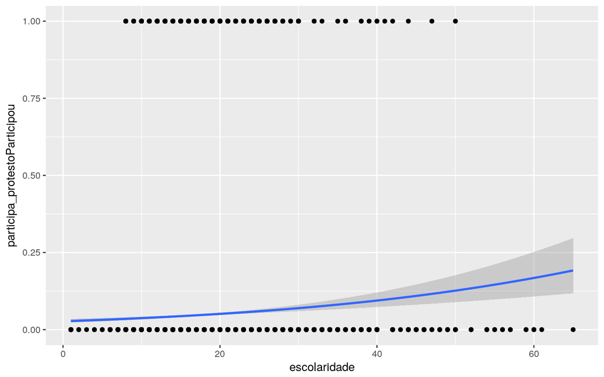

```r
# carregar pacote
library(ggplot2)

# contruir grafico de dispersao
ggplot(databaseClean, aes(x = escolaridade, y = participa_protestoParticipou)) +
    geom_point() + stat_smooth(method = "glm", method.args = list(family = "binomial"))
```

## Regressão Logística Multinomial (Multinomial Logit Reg.)

Quando no fenômeno que desejamos explicar ou predizer assume valores nominais, podemos usar uma regressão logística multinomial. Tomando uma das categorias como base de referência para comparar com as demais, estimamos os efeitos das variáveis independentes sobre a chance da manifestação de cada fenômeno (categoria) em relação a categoria base. Por exemplo, no nosso primeiro modelo vamos estimar o efeito da percepção da `violencia policial` (presença de violência policial quase todos os dias) sobre a chance de `não votar nem protestar`, em relação a `votar e também protestar`.

```r
# carregar pacote
library("nnet")
```

```r
# recodificar VD
databaseClean$interesse_politicoRecod <- factor(databaseClean$interesse_político,
    levels = c(1, 2, 3, 4, 5), labels = c("votar sempre", "votar e também protestar",
        "só protestar e não serve votar", "não votar e nem protestar", "nao sei"))

# Definir a categoria de parametro para comparacao
databaseClean$interesse_politicoRecod <- relevel(databaseClean$interesse_politicoRecod,
    ref = "votar e também protestar")
```

```r
#---------------------------------#
# MODELO MULTINOM
#---------------------------------#

modelo1 <- multinom(interesse_politicoRecod ~ violenciaPolicialTodosDias + esgotamentoSim +
    escolaridade + classeBaixa + generoMulher + racaNegroMulato, data = databaseClean)
# visualizar resultados
summary(modelo1)
```

```
Call:
multinom(formula = interesse_politicoRecod ~ violenciaPolicialTodosDias +
    esgotamentoSim + escolaridade + classeBaixa + generoMulher +
    racaNegroMulato, data = databaseClean)

Coefficients:
                               (Intercept) violenciaPolicialTodosDias
votar sempre                      1.177738                 -0.1306275
só protestar e não serve votar   -2.050832                  0.4425512
não votar e nem protestar        -1.137617                  0.5761530
nao sei                          -1.152381                 -0.1002247
                               esgotamentoSim escolaridade classeBaixa
votar sempre                    -0.0005009614  -0.03230564 -0.04008623
só protestar e não serve votar   0.1535971513  -0.01882481 -0.01042256
não votar e nem protestar       -0.1390280527  -0.06324888  0.24915805
nao sei                          0.1240592463  -0.05581253  0.21484384
                               generoMulher racaNegroMulato
votar sempre                    0.007137787     -0.11549226
só protestar e não serve votar -0.307381081      0.02929496
não votar e nem protestar       0.122599175      0.28368538
nao sei                         0.304359003     -0.10509015

Std. Errors:
                               (Intercept) violenciaPolicialTodosDias
votar sempre                    0.07275563                 0.08026483
só protestar e não serve votar  0.20200379                 0.18056825
não votar e nem protestar       0.18799188                 0.15491261
nao sei                         0.16672044                 0.17706576
                               esgotamentoSim escolaridade classeBaixa
votar sempre                       0.04350341  0.003449727  0.04830627
só protestar e não serve votar     0.12318136  0.009638619  0.13231875
não votar e nem protestar          0.10147486  0.009891778  0.10777427
nao sei                            0.09394694  0.008416846  0.09727341
                               generoMulher racaNegroMulato
votar sempre                     0.03764087       0.0629138
só protestar e não serve votar   0.10452249       0.1650628
não votar e nem protestar        0.09216663       0.1353162
nao sei                          0.08181360       0.1383101

Residual Deviance: 29666.12
AIC: 29722.12
```

```r
# visualizar em log odds (razao de chance)
stargazer(modelo1, type = "text", title = "Resultados do Modelo", style = "ajps",
    apply.coef = exp, p.auto = FALSE)
```

```
Resultados do Modelo
----------------------------------------------------------------------------------------------------------
                           votar sempre só protestar e não serve votar não votar e nem protestar  nao sei
                             Model 1               Model 2                      Model 3           Model 4
----------------------------------------------------------------------------------------------------------
violenciaPolicialTodosDias    0.878                1.557**                     1.779***            0.905
                             (0.080)               (0.181)                      (0.155)           (0.177)
esgotamentoSim                0.999                 1.166                        0.870             1.132
                             (0.044)               (0.123)                      (0.101)           (0.094)
escolaridade                 0.968***               0.981*                     0.939***          0.946***
                             (0.003)               (0.010)                      (0.010)           (0.008)
classeBaixa                   0.961                 0.990                       1.283**           1.240**
                             (0.048)               (0.132)                      (0.108)           (0.097)
generoMulher                  1.007                0.735***                      1.130           1.356***
                             (0.038)               (0.105)                      (0.092)           (0.082)
racaNegroMulato               0.891*                1.030                       1.328**            0.900
                             (0.063)               (0.165)                      (0.135)           (0.138)
Constant                     3.247***              0.129***                    0.321***          0.316***
                             (0.073)               (0.202)                      (0.188)           (0.167)
AIC                         29722.120             29722.120                    29722.120         29722.120
----------------------------------------------------------------------------------------------------------
***p < .01; **p < .05; *p < .1
```

## Modelo de Regressão Ordinal (Cumulative Link Models)

O modelo de regressão ordinal se baseia no cálculo do efeito da VI em relação ao aumento de uma unidade na VD, ou seja o efeito médio de “saltar” de uma categoria mais baixa para uma mais alta.

### Pacotes

```r
install.packages("ordinal")
library(ordinal)
```

```r
library(ordinal)
```

```r
#---------------------------------#
# MODELO CLM
#---------------------------------#

# executar modelo
modelo1 <- clm(conversa_sobre_politicaOrd ~ violenciaPolicialTodosDias + esgotamentoSim +
    escolaridade + classeBaixa + generoMulher + racaNegroMulato, data = databaseClean)

# visualizar resultados do modelo
summary(modelo1)
```

```
formula:
conversa_sobre_politicaOrd ~ violenciaPolicialTodosDias + esgotamentoSim + escolaridade + classeBaixa + generoMulher + racaNegroMulato
data:    databaseClean

 link  threshold nobs  logLik    AIC      niter max.grad cond.H
 logit flexible  14043 -17263.00 34544.00 5(0)  2.54e-08 1.7e+04

Coefficients:
                            Estimate Std. Error z value Pr(>|z|)
violenciaPolicialTodosDias  0.180671   0.066634   2.711   0.0067 **
esgotamentoSim              0.100248   0.035952   2.788   0.0053 **
escolaridade                0.056771   0.002997  18.943  < 2e-16 ***
classeBaixa                -0.260704   0.040086  -6.504 7.84e-11 ***
generoMulher               -0.544990   0.031283 -17.421  < 2e-16 ***
racaNegroMulato             0.085711   0.052749   1.625   0.1042
---
Signif. codes:  0 '***' 0.001 '**' 0.01 '*' 0.05 '.' 0.1 ' ' 1

Threshold coefficients:
                                Estimate Std. Error z value
nunca|quase nunca                0.15029    0.06120   2.456
quase nunca|frequentemente       1.66196    0.06285  26.444
frequentemente|muita frequência  3.41853    0.06999  48.842
```

```r
# visualizar em odds ratio (razao de chance)
stargazer(modelo1, type = "text", title = "Resultados Modelo 1", style = "ajps",
    apply.coef = exp, p.auto = FALSE)
```

```
Resultados Modelo 1
-----------------------------------------------------
                           conversa_sobre_politicaOrd
-----------------------------------------------------
violenciaPolicialTodosDias          1.198***
                                    (0.067)
esgotamentoSim                      1.105***
                                    (0.036)
escolaridade                        1.058***
                                    (0.003)
classeBaixa                         0.771***
                                    (0.040)
generoMulher                        0.580***
                                    (0.031)
racaNegroMulato                      1.089
                                    (0.053)
N                                    14043
Log Likelihood                     -17263.000
-----------------------------------------------------
***p < .01; **p < .05; *p < .1
```

### Referências

https://www.analyticsvidhya.com/blog/2016/02/multinomial-ordinal-logistic-regression/ https://rpubs.com/rslbliss/r_logistic_ws

# Introdução à Programação em R

Uma das melhores funcionalidades do R é a possibilidade de construção de funções e consequente automatização de processos. Por ser uma linguagem de programação, o R possibilita o desenvolvimento de códigos e comandos que podem ser aplicados a diferentes contextos, reduzindo o trabalho de um analista que precisa executar o mesmo trabalho diversas vezes. Começando simples, vamos desenvolver nossa primeira função, a `nossaMedia()`.

```r
# criar funcao de media (soma dos valores divida pelo numero de casos)
nossaMedia <- function(x) {

    media = sum(x)/length(x)

    return(media)
}

# testar funcao
nossaMedia(databaseClean$escolaridade)
```

```
[1] 17.44869
```

```r
mean(databaseClean$escolaridade)
```

```
[1] 17.44869
```

## Praticar

Para praticar um pouco tente criar uma funcao que retorna um `dataframe` resultante da contagem de uma variavel categorica no banco de dados, de modo que possamos visualizar as categorias daquela variavel e quantos casos há em cada categoria.

## Execício

Para aplicar esse conhecimento neste projeto, tente criar uma funcao que execute os modelos de regressão logística binomial necessários, em que os argumentos dessa função sejam o banco de dados e a variavel dependente. Desse modo, como todas as demais variaveis serão as mesmas para cada modelo, podemos automatizar a execução dos modelos, nos poupando tempo e linhas de código ;)

Cláudio A. Monteiro

Outubro, 2018